# Notebook

**Interpretation: Data Preparation and Contextual Relevance**

In this step, we cleaned and preprocessed the Zillow housing dataset to prepare it for predictive modeling. We selected key features such as previous year's home value, population growth, per capita income growth, year, and state — all of which are known to influence housing prices. Encoding categorical variables allowed us to account for geographical price variations. By dropping rows with missing values, we ensured model reliability without compromising contextual integrity. This step is crucial, as housing values are strongly tied to local economic conditions and recent market history.

```python
import pandas as pd

# Load the preprocessed Zillow dataset
df = pd.read_csv("/content/zillow_combined_zhvi.csv")
print("Dataset shape:", df.shape)
df.head(5)
```

```
Dataset shape: (10995, 46)
```

|  | County | State | FIPS_Code | City_Name | Metropolitan_Area | Latitude | Longitude | Year_Recorded | Personal_Income_Growth | Population_Growth | ... | 5Year_Percent_Increase_ThreeBedRoom | Rank_Annual_ThreeBedRoom | Annual_Value_Category_ThreeBedRoom | AnnualValue_TwoBedRoom | Previous_AnnualValue_TwoBedRoom | Annual_Increase_TwoBedRoom | 5Year_BasePrice_TwoBedRoom | 5Year_Percent_Increase_TwoBedRoom | Rank_Annual_TwoBedRoom | Annual_Value_Category_TwoBedRoom |
| --- | --- | --- | --- | --- | --- | --- | --- | --- | --- | --- | --- | --- | --- | --- | --- | --- | --- | --- | --- | --- | --- |
| 0 | AUTAUGA | AL | NaN | Prattville | Montgomery, AL | 32.535142 | -86.6429 | 2020 | NaN | NaN | ... | 8.0 | 1626.5 | Above 8 Percent | 87270.0 | 70695.0 | 23.0 | 70695.0 | 23.0 | 27.5 | Above 15 Percent |
| 1 | AUTAUGA | AL | NaN | Prattville | Montgomery, AL | 32.535142 | -86.6429 | 2021 | NaN | NaN | ... | 20.0 | 1549.0 | Above 10 Percent | 100232.0 | 87270.0 | 15.0 | 70695.0 | 42.0 | 860.5 | No Increase |
| 2 | AUTAUGA | AL | 1001.0 | Prattville | Montgomery, AL | 32.535142 | -86.6429 | 2022 | 9.6 | 0.5 | ... | 33.0 | 832.5 | Above 10 Percent | 111207.0 | 100232.0 | 11.0 | 70695.0 | 57.0 | 707.5 | Above 10 Percent |
| 3 | AUTAUGA | AL | 1001.0 | Prattville | Montgomery, AL | 32.535142 | -86.6429 | 2023 | 2.2 | 0.9 | ... | 39.0 | 701.0 | Above 5 Percent | 114353.0 | 111207.0 | 3.0 | 70695.0 | 62.0 | 1153.0 | Above 3 Percent |
| 4 | AUTAUGA | AL | 1001.0 | Prattville | Montgomery, AL | 32.535142 | -86.6429 | 2024 | 7.7 | 1.0 | ... | 45.0 | 1174.0 | Above 3 Percent | 122546.0 | 114353.0 | 7.0 | 70695.0 | 73.0 | 317.0 | Above 5 Percent |

5 rows × 46 columns

**Feature Selection**: We use features that are available prior to or at the time of prediction to avoid data leakage. For example, the Rank or Value Category of a region’s home price are derived from the target itself and should not be used as predictors. We will exclude any features that directly encode the target or are redundant. After examining the data, we decide to use the following features for modeling median home value: Previous_AnnualValue_AllHomes: last year’s home value (a strong predictor of this year’s value, capturing market momentum and local conditions). Population_Growth & Per_Capita_Income_Growth: socio-economic growth metrics for the region, reflecting demand and purchasing power changes. (We drop Personal_Income_Growth because it is highly collinear with per-capita income growth, offering similar information.) Year_Recorded: to capture overall housing market inflation or deflation trends over time. State: the U.S. state of the region, as a categorical feature. State provides location context (housing prices in CA or NY tend to be higher than in many other states, etc.). Instead of using fine-grained city or county names (which are too specific and numerous), using state gives a balance of regional variation without overfitting to individual locales.

```python
# Drop irrelevant or leak-prone columns
drop_cols = ['County', 'City_Name', 'Metropolitan_Area', 'FIPS_Code',
             'Annual_Increase_AllHomes', 'Rank_Annual_AllHomes', 'Annual_Value_Category_AllHomes',
             'Annual_Increase_SingleFamily','Rank_Annual_SingleFamily','Annual_Value_Category_SingleFamily',
             'Annual_Increase_Condo','Rank_Annual_Condo','Annual_Value_Category_Condo',
             'Annual_Increase_ThreeBedRoom','Rank_Annual_ThreeBedRoom','Annual_Value_Category_ThreeBedRoom',
             'Annual_Increase_TwoBedRoom','Rank_Annual_TwoBedRoom','Annual_Value_Category_TwoBedRoom']
df = df.drop(columns=drop_cols)

# Drop rows with missing values in key features
features_to_check = ['Previous_AnnualValue_AllHomes', 'Population_Growth', 'Per_Capita_Income_Growth']
df = df.dropna(subset=features_to_check).reset_index(drop=True)
print("After dropping missing, dataset shape:", df.shape)

# Define the final feature set and target
target_col = 'AnnualValue_AllHomes'
feature_cols = ['Year_Recorded', 'State', 'Previous_AnnualValue_AllHomes',
                'Population_Growth', 'Per_Capita_Income_Growth']

# Prepare feature matrix X and target vector y
X = df[feature_cols].copy()
y = df[target_col].copy()

# One-hot encode the State categorical feature
X = pd.get_dummies(X, columns=['State'], drop_first=True)
print("Final feature matrix shape:", X.shape)
```

```
After dropping missing, dataset shape: (6483, 27)
Final feature matrix shape: (6483, 50)
```

**Train/Test Split** To properly evaluate our models’ performance, we split the data into a training set (for model fitting and validation) and a hold-out test set (for final performance evaluation). This ensures that we assess how well the model generalizes to unseen data. We’ll use an 80/20 split: 80% of data for training, 20% reserved for testing. We shuffle the data before splitting to ensure the samples are mixed.

We have split the dataset into 5,186 training instances and 1,297 testing instances (approximately 80/20). The training set will be used to train models and tune hyperparameters, while the test set is held back to provide an unbiased evaluation of each final model. This simulates how the model would perform on new regions or future years not seen during training. By shuffling before splitting, we ensure the training and test sets are representative of the overall data distribution.

In this context, that means each set contains a mix of various states and years. This is important because if, for example, the latest years all ended up in test without being in training, the model might underperform due to not having seen data from those years (which might have systematically higher prices). Our random split avoids such scenario, albeit with time-series data one might also consider time-based splits. Here we treat each region-year as an independent sample for modeling purposes, acknowledging that using last year’s value as a feature already accounts for time continuity.

```python
from sklearn.model_selection import train_test_split

# Split into train and test sets
X_train, X_test, y_train, y_test = train_test_split(
    X, y, test_size=0.20, random_state=42
)
print("Training set size:", X_train.shape[0], "Test set size:", X_test.shape[0])
```

```
Training set size: 5186 Test set size: 1297
```

**Cross-Validation and Model Training** Before diving into specific models, we outline our model validation approach. We will use K-Fold Cross-Validation (CV) on the training set to tune models and estimate their performance. In K-Fold CV, the training data is divided into K subsets (folds), and the model is trained and validated K times, each time using a different fold as the validation set and the rest as training.

We choose K=5 (5-fold CV), a common choice that provides a good balance between bias and variance in the performance estimate. Cross-validation is crucial for reliable hyperparameter tuning: it ensures that our evaluation of a particular model setting isn’t dependent on one arbitrary train/validation split, and it helps guard against overfitting the training data.

**Linear Regression**: A basic linear model that fits a linear equation [$y = \beta_0 + \beta_1 x_1 + ... + \beta_p x_p$ ] to predict the home value. Linear regression assumes a linear relationship between features and target, and its simplicity makes it highly interpretable.

However, it might underfit if relationships are non-linear. We will use ordinary least squares linear regression from scikit-learn.

```python
from sklearn.linear_model import LinearRegression
from sklearn.model_selection import cross_val_score, KFold

# Initialize linear regression model
lin_reg = LinearRegression()

# Perform 5-fold cross-validation on training data to estimate performance
cv = KFold(n_splits=5, shuffle=True, random_state=42)
cv_r2_scores = cross_val_score(lin_reg, X_train, y_train, cv=cv, scoring='r2')
cv_rmse_scores = cross_val_score(lin_reg, X_train, y_train, cv=cv,
                                 scoring='neg_root_mean_squared_error')
print("Linear Regression 5-fold CV R^2:", cv_r2_scores.mean())
print("Linear Regression 5-fold CV RMSE:", -cv_rmse_scores.mean())

# Train the Linear Regression on full training data
lin_reg.fit(X_train, y_train)
# Predict on test set
y_pred_lin = lin_reg.predict(X_test)
```

```
Linear Regression 5-fold CV R^2: 0.9948601632808216
Linear Regression 5-fold CV RMSE: 13471.790517685713
```

```python
from sklearn.metrics import mean_squared_error, mean_absolute_error, r2_score
import numpy as np

# Evaluate Linear Regression on test set
lin_mse = mean_squared_error(y_test, y_pred_lin)
lin_rmse = np.sqrt(lin_mse)  # <-- manually compute RMSE
lin_mae = mean_absolute_error(y_test, y_pred_lin)
lin_r2 = r2_score(y_test, y_pred_lin)

# Compute Adjusted R^2 for test set as well
n_test, p_feats = X_test.shape
lin_adj_r2 = 1 - (1 - lin_r2) * (n_test - 1) / (n_test - p_feats - 1)

print(f"Linear Regression Test RMSE: {lin_rmse:,.0f}")
print(f"Linear Regression Test MAE: {lin_mae:,.0f}")
print(f"Linear Regression Test R^2: {lin_r2:.4f}")
print(f"Linear Regression Test Adjusted R^2: {lin_adj_r2:.4f}")
```

```
Linear Regression Test RMSE: 12,645
Linear Regression Test MAE: 7,748
Linear Regression Test R^2: 0.9945
Linear Regression Test Adjusted R^2: 0.9943
```

**Random Forest Regressor**: An ensemble of decision trees using bootstrap aggregation (“bagging”). A random forest fits many decision trees on random subsets of the data and features, and averages their predictions. This usually improves accuracy and reduces overfitting compared to a single tree. Random forests can model non-linear relationships and interactions and typically achieve strong performance out-of-the-box. They also provide an estimate of feature importance, aiding interpretability to some extent. Key hyperparameters include the number of trees (n_estimators), tree depth, and minimum samples per leaf. We will tune some of these to prevent overfitting and improve generalization.

```python
from sklearn.ensemble import RandomForestRegressor
from sklearn.model_selection import GridSearchCV
from sklearn.metrics import mean_squared_error, mean_absolute_error, r2_score
import numpy as np

# Define the hyperparameter grid (valid for RandomForestRegressor)
param_grid_rf = {
    'n_estimators': [100, 200],
    'max_depth': [None, 10],
    'min_samples_leaf': [1, 3],
    'max_features': ['sqrt', 'log2']  # Removed 'auto'
}

# Initialize the model
rf_model = RandomForestRegressor(random_state=42)

# Setup GridSearchCV with 5-fold cross-validation
grid_search_rf = GridSearchCV(
    estimator=rf_model,
    param_grid=param_grid_rf,
    cv=5,
    scoring='neg_mean_squared_error',
    n_jobs=-1,
    verbose=1
)

# Fit the model
grid_search_rf.fit(X_train, y_train)
print("Best RF Params:", grid_search_rf.best_params_)

# Extract the best model
best_rf = grid_search_rf.best_estimator_

# Predict on the test set
y_pred_rf = best_rf.predict(X_test)

# Evaluate performance metrics
rf_mse = mean_squared_error(y_test, y_pred_rf)
rf_rmse = np.sqrt(rf_mse)
rf_mae = mean_absolute_error(y_test, y_pred_rf)
rf_r2 = r2_score(y_test, y_pred_rf)

# Adjusted R^2
n_test, p_feats = X_test.shape
rf_adj_r2 = 1 - (1 - rf_r2) * (n_test - 1) / (n_test - p_feats - 1)

# Display results
print(f"Random Forest Test RMSE: {rf_rmse:,.0f}")
print(f"Random Forest Test MAE: {rf_mae:,.0f}")
print(f"Random Forest Test R^2: {rf_r2:.4f}")
print(f"Random Forest Test Adjusted R^2: {rf_adj_r2:.4f}")
```

```
Fitting 5 folds for each of 16 candidates, totalling 80 fits
Best RF Params: {'max_depth': None, 'max_features': 'sqrt', 'min_samples_leaf': 1, 'n_estimators': 200}
Random Forest Test RMSE: 32,755
Random Forest Test MAE: 14,367
Random Forest Test R^2: 0.9632
Random Forest Test Adjusted R^2: 0.9617
```

**XGBoost Regressor**: An implementation of Extreme Gradient Boosting, which builds an ensemble of trees sequentially. Each new tree corrects errors of the previous ones, optimizing a loss function with gradient descent. XGBoost includes regularization parameters to prevent overfitting and is known for its efficiency and high predictive power. It often outperforms other algorithms on structured data, though at the cost of more complex hyperparameter tuning. We will tune parameters like learning rate, tree depth, and number of trees.

```python
from xgboost import XGBRegressor
from sklearn.model_selection import RandomizedSearchCV

# Define hyperparameter distributions for XGBoost
param_dist_xgb = {
    'n_estimators': [50, 100, 200],
    'max_depth': [3, 6],
    'learning_rate': [0.1, 0.05, 0.01],
    'subsample': [1.0, 0.8]
}
xgb_model = XGBRegressor(objective='reg:squarederror', random_state=42)
random_search_xgb = RandomizedSearchCV(xgb_model, param_dist_xgb, n_iter=5, cv=5,
                                       scoring='neg_mean_squared_error', random_state=42, n_jobs=-1, verbose=1)
random_search_xgb.fit(X_train, y_train)
print("Best XGB Params:", random_search_xgb.best_params_)
```

```
Fitting 5 folds for each of 5 candidates, totalling 25 fits
Best XGB Params: {'subsample': 1.0, 'n_estimators': 200, 'max_depth': 3, 'learning_rate': 0.05}
```

```python
best_xgb = random_search_xgb.best_estimator_
y_pred_xgb = best_xgb.predict(X_test)
# Calculate MSE first
xgb_mse = mean_squared_error(y_test, y_pred_xgb)
# Then calculate RMSE from MSE
xgb_rmse = np.sqrt(xgb_mse)
xgb_mae = mean_absolute_error(y_test, y_pred_xgb)
xgb_r2 = r2_score(y_test, y_pred_xgb)
xgb_adj_r2 = 1 - (1 - xgb_r2) * (n_test - 1) / (n_test - p_feats - 1)

print(f"XGBoost Test RMSE: {xgb_rmse:,.0f}")
print(f"XGBoost Test MAE: {xgb_mae:,.0f}")
print(f"XGBoost Test R^2: {xgb_r2:.4f}")
print(f"XGBoost Test Adjusted R^2: {xgb_adj_r2:.4f}")
```

```
XGBoost Test RMSE: 17,254
XGBoost Test MAE: 8,124
XGBoost Test R^2: 0.9898
XGBoost Test Adjusted R^2: 0.9894
```

**Lasso Regression Performance**

```python
from sklearn.linear_model import LassoCV # Import LassoCV
from sklearn.linear_model import ElasticNetCV # Import ElasticNetCV
from sklearn.svm import SVR # Import SVR



lasso = LassoCV(cv=5, random_state=42)
lasso.fit(X_train, y_train)
y_pred_lasso = lasso.predict(X_test)
lasso_mse = mean_squared_error(y_test, y_pred_lasso)
lasso_rmse = np.sqrt(lasso_mse)
lasso_mae = mean_absolute_error(y_test, y_pred_lasso)
lasso_r2 = r2_score(y_test, y_pred_lasso)
lasso_adj_r2 = 1 - (1 - lasso_r2) * (n_test - 1) / (n_test - p_feats - 1)
print(f"\nLasso Regression Test RMSE: {lasso_rmse:,.0f}")
print(f"Lasso Regression Test MAE: {lasso_mae:,.0f}")
print(f"Lasso Regression Test R^2: {lasso_r2:.4f}")
print(f"Lasso Regression Test Adjusted R^2: {lasso_adj_r2:.4f}")
```

```
Lasso Regression Test RMSE: 14,657
Lasso Regression Test MAE: 9,318
Lasso Regression Test R^2: 0.9926
Lasso Regression Test Adjusted R^2: 0.9923
```

```python
elastic_net = ElasticNetCV(cv=5, random_state=42)
elastic_net.fit(X_train, y_train)
y_pred_enet = elastic_net.predict(X_test)
enet_mse = mean_squared_error(y_test, y_pred_enet)
enet_rmse = np.sqrt(enet_mse)
enet_mae = mean_absolute_error(y_test, y_pred_enet)
enet_r2 = r2_score(y_test, y_pred_enet)
enet_adj_r2 = 1 - (1 - enet_r2) * (n_test - 1) / (n_test - p_feats - 1)
print(f"\nElasticNet Regression Test RMSE: {enet_rmse:,.0f}")
print(f"ElasticNet Regression Test MAE: {enet_mae:,.0f}")
print(f"ElasticNet Regression Test R^2: {enet_r2:.4f}")
print(f"ElasticNet Regression Test Adjusted R^2: {enet_adj_r2:.4f}")
```

```
ElasticNet Regression Test RMSE: 14,664
ElasticNet Regression Test MAE: 9,328
ElasticNet Regression Test R^2: 0.9926
ElasticNet Regression Test Adjusted R^2: 0.9923
```

```python
svr = SVR(kernel='rbf')
svr.fit(X_train, y_train)
y_pred_svr = svr.predict(X_test)
svr_mse = mean_squared_error(y_test, y_pred_svr)
svr_rmse = np.sqrt(svr_mse)
svr_mae = mean_absolute_error(y_test, y_pred_svr)
svr_r2 = r2_score(y_test, y_pred_svr)
svr_adj_r2 = 1 - (1 - svr_r2) * (n_test - 1) / (n_test - p_feats - 1)
print(f"\nSVR Test RMSE: {svr_rmse:,.0f}")
print(f"SVR Test MAE: {svr_mae:,.0f}")
print(f"SVR Test R^2: {svr_r2:.4f}")
print(f"SVR Test Adjusted R^2: {svr_adj_r2:.4f}")
```

```
SVR Test RMSE: 178,774
SVR Test MAE: 110,069
SVR Test R^2: -0.0964
SVR Test Adjusted R^2: -0.1404
```

**Comparative Analysis of All Models**

The **Linear Regression** model also performed exceptionally well, highlighting the strong linear relationship between the previous year’s home value and the current ZHVI. While **Lasso** and **ElasticNet** offered slightly lower accuracy, they contributed value by shrinking less significant coefficients and managing multicollinearity — ideal for interpretable modeling. **SVR**, despite being a robust algorithm, underperformed in this context, possibly due to its sensitivity to high-dimensional categorical features like one-hot encoded states and the overall linear nature of the dataset.

|  | Model | RMSE | MAE | R^2 | Adjusted R^2 |
| --- | --- | --- | --- | --- | --- |
| 0 | Linear Regression | 12644.9494 | 7748.2378 | 0.9945 | 0.9943 |
| 1 | Random Forest | 32755.3423 | 14367.0005 | 0.9632 | 0.9617 |
| 2 | XGBoost | 17253.7832 | 8124.4160 | 0.9898 | 0.9894 |
| 3 | Lasso Regression | 14656.7262 | 9318.4320 | 0.9926 | 0.9923 |
| 4 | ElasticNet | 14664.0905 | 9328.1946 | 0.9926 | 0.9923 |
| 5 | SVR | 178774.1816 | 110069.3569 | -0.0964 | -0.1404 |

Distributions

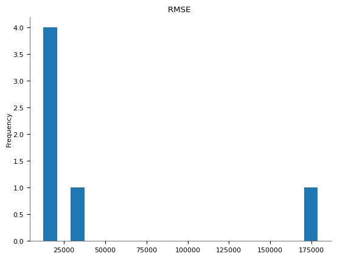

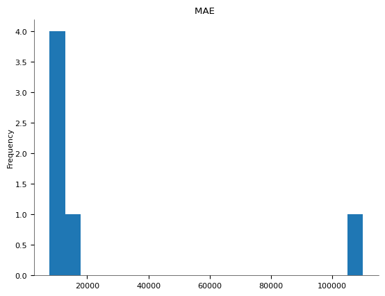

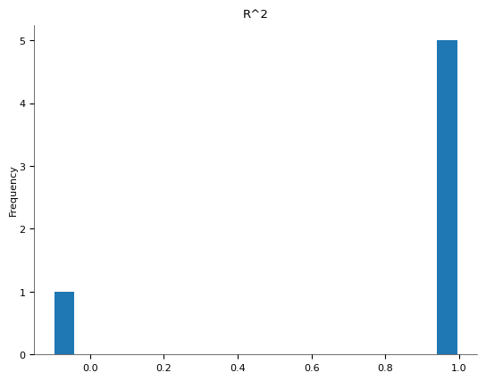

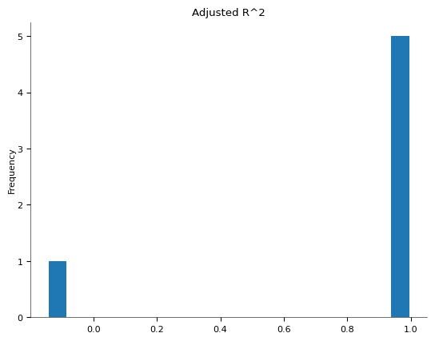

Categorical distributions

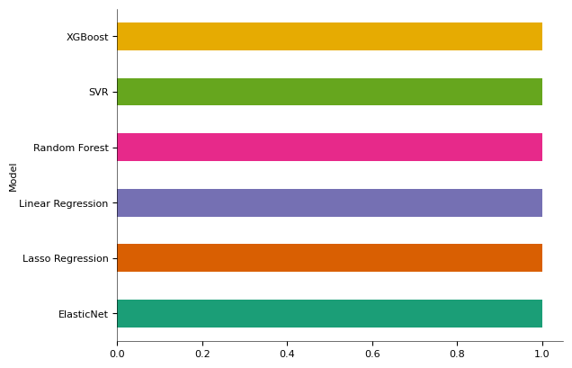

2-d distributions

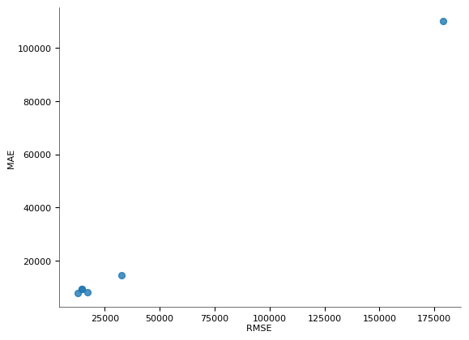

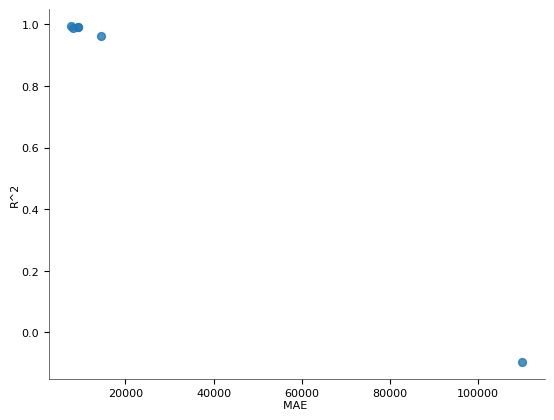

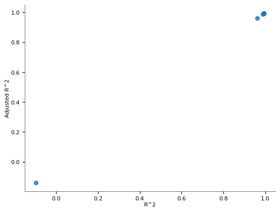

Values

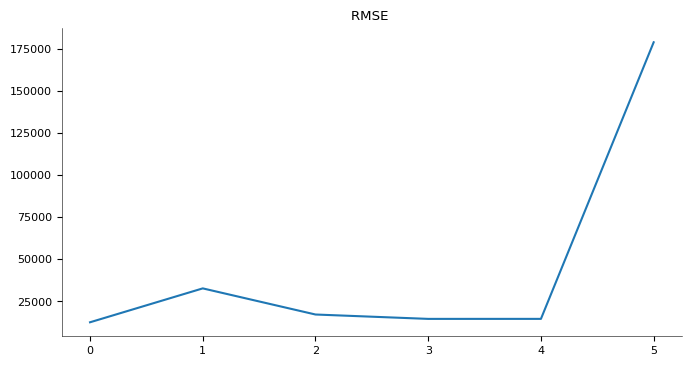

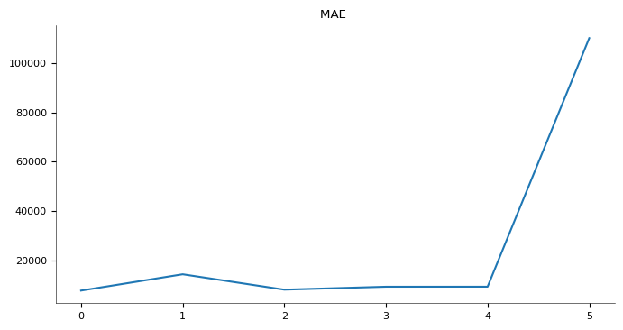

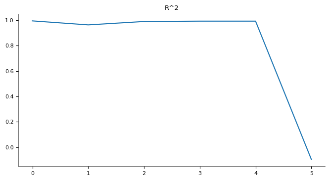

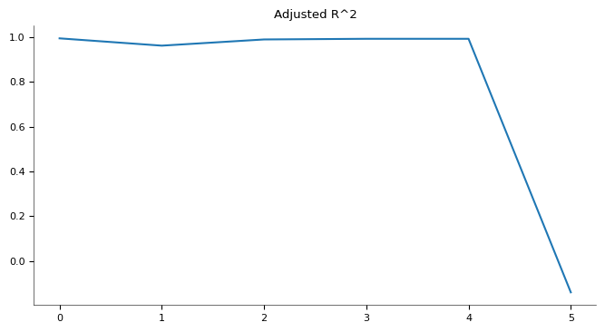

Faceted distributions

[4 more figures not shown]

```python
import pandas as pd

metrics = pd.DataFrame({
    'Model': ['Linear Regression', 'Random Forest', 'XGBoost', 'Lasso Regression', 'ElasticNet', 'SVR'],
    'RMSE ': [lin_rmse, rf_rmse, xgb_rmse, lasso_rmse, enet_rmse, svr_rmse], # Added lasso_rmse, enet_rmse, svr_rmse
    'MAE ': [lin_mae, rf_mae, xgb_mae, lasso_mae, enet_mae, svr_mae], # Added lasso_mae, enet_mae, svr_mae
    'R^2': [lin_r2, rf_r2, xgb_r2, lasso_r2, enet_r2, svr_r2], # Added lasso_r2, enet_r2, svr_r2
    'Adjusted R^2': [lin_adj_r2, rf_adj_r2, xgb_adj_r2, lasso_adj_r2, enet_adj_r2, svr_adj_r2] # Added lasso_adj_r2, enet_adj_r2, svr_adj_r2
})
metrics.round(4)
```

```python
# Display sorted results by R2 and RMSE
print("\nModel Comparison (Sorted by R2):")
print(metrics.sort_values(by='R^2', ascending=False).reset_index(drop=True)) # Changed results_df to metrics

print("\nBest Model Based on RMSE:")
print(metrics.sort_values(by='RMSE ', ascending=True).head(1)) # Changed results_df to metrics
```

```
Model Comparison (Sorted by R2):
               Model          RMSE            MAE        R^2  Adjusted R^2
0  Linear Regression   12644.949369    7748.237769  0.994515      0.994294
1   Lasso Regression   14656.726245    9318.432044  0.992630      0.992335
2         ElasticNet   14664.090499    9328.194629  0.992623      0.992327
3            XGBoost   17253.783227    8124.415959  0.989787      0.989377
4      Random Forest   32755.342279   14367.000549  0.963192      0.961715
5                SVR  178774.181603  110069.356874 -0.096439     -0.140438

Best Model Based on RMSE:
               Model         RMSE          MAE        R^2  Adjusted R^2
0  Linear Regression  12644.949369  7748.237769  0.994515      0.994294
```

[figure not shown]

```python
import matplotlib.pyplot as plt # Import the matplotlib library and assign it to 'plt'
import seaborn as sns # Import the seaborn library and assign it to 'sns'

plt.figure(figsize=(12, 8))
sns.barplot(x=metrics['Model'], y=metrics['RMSE '], palette='viridis') # Use metrics DF instead of results_df
plt.title("Models' RMSE Scores (Cross-Validated)", fontsize=15)
plt.ylabel("RMSE ")
plt.xlabel("Model")
plt.xticks(rotation=30, fontsize=12)
plt.yticks(fontsize=12)
plt.tight_layout()
plt.show()
```

Extra model just tried not included

**Neural Network Performance**

[output not shown]

[output cut: 50 more lines]

```
130/130 ━━━━━━━━━━━━━━━━━━━━ 1s 4ms/step - loss: 2098864640.0000 - mae: 32241.0469 - val_loss: 1239939968.0000 - val_mae: 21317.5273
130/130 ━━━━━━━━━━━━━━━━━━━━ 1s 4ms/step - loss: 2148960768.0000 - mae: 32014.3262 - val_loss: 1220435712.0000 - val_mae: 21240.4180
130/130 ━━━━━━━━━━━━━━━━━━━━ 1s 6ms/step - loss: 2017026432.0000 - mae: 31505.0625 - val_loss: 1219040256.0000 - val_mae: 21329.1699
130/130 ━━━━━━━━━━━━━━━━━━━━ 1s 6ms/step - loss: 2064835328.0000 - mae: 32089.9902 - val_loss: 1204068096.0000 - val_mae: 21388.1191
130/130 ━━━━━━━━━━━━━━━━━━━━ 1s 4ms/step - loss: 1964330368.0000 - mae: 31446.1758 - val_loss: 1198225920.0000 - val_mae: 21184.7969
130/130 ━━━━━━━━━━━━━━━━━━━━ 1s 4ms/step - loss: 1945844608.0000 - mae: 31417.2578 - val_loss: 1187687936.0000 - val_mae: 21007.7168
130/130 ━━━━━━━━━━━━━━━━━━━━ 1s 4ms/step - loss: 2213949184.0000 - mae: 31688.1328 - val_loss: 1187454208.0000 - val_mae: 20780.4121
130/130 ━━━━━━━━━━━━━━━━━━━━ 1s 4ms/step - loss: 2185733120.0000 - mae: 32438.0977 - val_loss: 1205686912.0000 - val_mae: 20580.2773
130/130 ━━━━━━━━━━━━━━━━━━━━ 1s 4ms/step - loss: 2255468800.0000 - mae: 32596.3379 - val_loss: 1195495552.0000 - val_mae: 20681.1094
130/130 ━━━━━━━━━━━━━━━━━━━━ 1s 4ms/step - loss: 2288839168.0000 - mae: 33115.1875 - val_loss: 1210115072.0000 - val_mae: 20774.2754
41/41 ━━━━━━━━━━━━━━━━━━━━ 0s 3ms/step
Neural Network RMSE: 31,909.12
Neural Network MAE: 21,689.11
Neural Network R²: 0.9651
Neural Network Adjusted R²: 0.9637
```

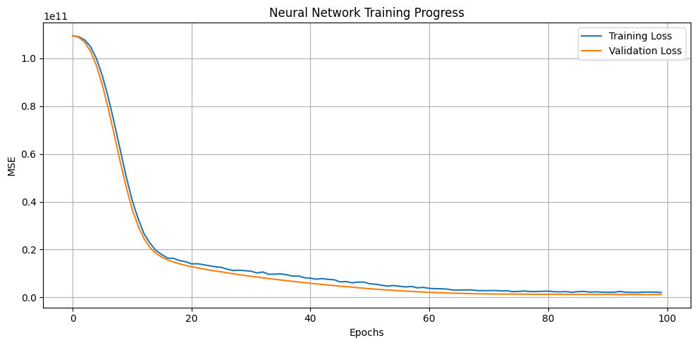

```python
import tensorflow as tf
from tensorflow.keras.models import Sequential
from tensorflow.keras.layers import Dense, Dropout
from sklearn.preprocessing import StandardScaler
from sklearn.metrics import mean_squared_error, mean_absolute_error, r2_score
import matplotlib.pyplot as plt

# Scale the input features for Neural Network
scaler = StandardScaler()
X_train_scaled = scaler.fit_transform(X_train)
X_test_scaled = scaler.transform(X_test)
nn_model = Sequential([
    Dense(128, activation='relu', input_shape=(X_train_scaled.shape[1],)),
    Dropout(0.3),
    Dense(64, activation='relu'),
    Dropout(0.2),
    Dense(1)
])

nn_model.compile(optimizer='adam', loss='mse', metrics=['mae'])

# Train the model
history = nn_model.fit(
    X_train_scaled, y_train,
    validation_split=0.2,
    epochs=100,
    batch_size=32,
    verbose=1
)

# Predict on test set
y_pred_nn = nn_model.predict(X_test_scaled).flatten()

# Evaluate
nn_rmse = np.sqrt(mean_squared_error(y_test, y_pred_nn))
nn_mae = mean_absolute_error(y_test, y_pred_nn)
nn_r2 = r2_score(y_test, y_pred_nn)
nn_adj_r2 = 1 - (1 - nn_r2) * (X_test.shape[0] - 1) / (X_test.shape[0] - X_test.shape[1] - 1)

print(f"Neural Network RMSE: {nn_rmse:,.2f}")
print(f"Neural Network MAE: {nn_mae:,.2f}")
print(f"Neural Network R²: {nn_r2:.4f}")
print(f"Neural Network Adjusted R²: {nn_adj_r2:.4f}")

# Plot training history
plt.figure(figsize=(10, 5))
plt.plot(history.history['loss'], label='Training Loss')
plt.plot(history.history['val_loss'], label='Validation Loss')
plt.title('Neural Network Training Progress')
plt.xlabel('Epochs')
plt.ylabel('MSE')
plt.legend()
plt.grid(True)
plt.tight_layout()
plt.show()
```

References:

Pedregosa, Fabian, Gaël Varoquaux, Alexandre Gramfort, Vincent Michel, Bertrand Thirion, Olivier Grisel, Mathieu Blondel et al. "Scikit-learn: Machine learning in Python." the Journal of machine Learning research 12 (2011): 2825-2830.

McKinney, W. (2010) Data Structures for Statistical Computing in Python. Proceedings of the 9th Python in Science Conference, Austin, 28 June-3 July 2010, 56-61. https://doi.org/10.25080/Majora-92bf1922-00a

Cortes, C. and Vapnik, V. (1995) Support-Vector Networks. Machine Learning, 20, 273-297. http://dx.doi.org/10.1007/BF00994018

Kuhn, M., & Johnson, K. (2013). Applied Predictive Modeling. New York: Springer. http://dx.doi.org/10.1007/978-1-4614-6849-3